# Welcome to analytics!📊

## What is it?

This easy-to-use Python package contains analytical functions to assist the data scientist in data exploration.

## Main Features

Here are the things `analytics` does well:

- find correlations between features and a dependent variable and other features
- check correlation coeficent given a threshold
- checks variance inflation factors to test for multicollinearity
- repeat purchase rate, includes option to find rate between groups and print a nice plot
- check survival rates for number of orders and months active for all customers
- check survival rates for number of orders and months active grouped by field, includes option to print a nice plot
- build an eda report

## Where to get it

The source code is currently hosted on GitHub at: https://github.com/ocurateinc/customer-notebooks/tree/main/packages/ocurate

To download and use this package in your notebooks, run pip install:

```
 pip install -U  "ocurate @ git+ssh://git@github.com/ocurateinc/data-science.git@main#subdirectory=packages/ocurate/"
```

To use in a Python notebook run:

```
import ocurate.analytics as ocu_analytics
```

```python
import main as ocu_analytics

# This is to supress the warning messages (if any) generated in our code
import warnings
import pandas as pd
warnings.filterwarnings('ignore')
```

```python
from ocurate.utils import bq
orders = bq.query_bq('''select client_user_id as customer_id,
                                invoiceid as transaction_id,
                                transaction_date,
                                transaction_value,
                                first_createdat as first_transaction_date,
                                first_total as first_transaction_value,
                                first_invoiceid as first_transaction_id,
                                free_shipping,
                                skipquiz,
                                first_state,
                                plan,
                                first_buy3discount, first_coupondiscount,first_referaldiscount, first_plandiscount,
                                first_bool_refdiscount,
                                first_bool_buy3discount
                        from `ocurate.humnutrition_analysis.orders_sample`
                        limit 300000''')
```

```
Device defined for PYTYD: cuda
```

### Supplemental Functions

#### Fill Empty DataFrame Columns

fills null columns and returns the df will no nulls.

Parameters:

- **df** : dataframe with missing numerical and categorical columns
- **cat_fields** : an optional list of categorical features in the df that are to replace all nulls with 'missing'. If there is no list then no categorical fields will be filled.
- **num_fields** : an optional list of numerical features in the df that are to be replaced will all 0. If there is no list then no numerical fields will be filled.
- **rounded** : default to None but if set the round all the numerical feats to X decimal places

#### Get First Transaction

Given an orders dataframe find the first order using the transaction date and return the df with the new fields `first_transaction_date` and `first_transaction_value`. This function is not appropriate for clients who use a different field to identify a first order or clients with orders data that is not complete.

Parameters:

- **df** : the orders df that contains the fields `'customer_id', 'transaction_date', 'transaction_value'`

#### Get Last Transaction

Given an orders dataframe find the last order using the transaction date and return the df with the new fields `last_transaction_date` and `last_transaction_value`. This function is not appropriate for clients who use a different field to identify the most recent order or clients with orders data that is not complete.

Parameters:

- **df** : the orders df that contains the fields `'customer_id', 'transaction_date', 'transaction_value'`

#### Data Checks

Performs simple data checks on customers and transaction data. This function could be used alone or within a bigger report function like html_orders_report. The checks include:

- Transaction Summary Statistics
- Customer ID nulls and duplicates
- Datatypes
- Creation of last transaction, first transaction and first year ltv if does not exist already.
- Filling of null columns

Parameters:

- **df** : A dataframe with the fields `'customer_id', 'transaction_date', 'transaction_value'`
- **num_fields** : A list of numerical fields in the df . This parameter is optional and if left as None the function will choose the fields with dtypes of float and int as the numerical fields.
- **cat_fields** : A list of categorical fields in the df . This parameter is optional and if left as None the function will choose the fields with dtypes of string and object as the categorical fields.
- **inline** : Default false. If true then display all print statements of simple data checks.

```python
num_fields=['first_buy3discount', 'first_coupondiscount','first_referaldiscount', 'first_plandiscount','first_transaction_value','first_yearLTV']
cat_fields=['free_shipping','skipquiz','first_state','plan','first_bool_refdiscount', 'first_bool_buy3discount']
orders=ocu_analytics.report.data_checks(orders,num_fields=num_fields,cat_fields=cat_fields,inline=True)
```

```
<class 'pandas.core.frame.DataFrame'>
Int64Index: 295455 entries, 0 to 295454
Data columns (total 24 columns):
 #   Column                   Non-Null Count   Dtype
---  ------                   --------------   -----
 0   customer_id              295455 non-null  object
 1   transaction_id           295455 non-null  object
 2   transaction_date         295455 non-null  datetime64[ns]
 3   transaction_value        295455 non-null  float64
 4   first_transaction_date   295455 non-null  datetime64[ns]
 5   first_transaction_value  295455 non-null  float64
 6   first_transaction_id     295455 non-null  object
 7   free_shipping            295455 non-null  object
 8   skipquiz                 295455 non-null  object
 9   first_state              295455 non-null  object
 10  plan                     295455 non-null  object
 11  first_buy3discount       295455 non-null  object
 12  first_coupondiscount     295455 non-null  object
 13  first_referaldiscount    295455 non-null  object
 14  first_plandiscount       295455 non-null  object
 15  first_bool_refdiscount   295455 non-null  object
 16  first_bool_buy3discount  295455 non-null  object
 17  first_cohort_month_name  295455 non-null  object
 18  first_cohort_month       295455 non-null  int64
 19  first_cohort_year        295455 non-null  int64
 20  first_cohort_month_year  295455 non-null  object
 21  last_transaction_date    295455 non-null  datetime64[ns]
 22  last_transaction_value   295455 non-null  float64
 23  first_yearLTV            295455 non-null  float64
dtypes: datetime64[ns](3), float64(4), int64(2), object(15)
memory usage: 56.4+ MB
None

there are 42279 unique customer ids

There are 0 duplicated rows
there are 0 null customer ids
there are 0 null transaction_date
there are 0 null transaction_value

transaction dates range between 2019-01-01 00:00:00 and 2023-10-18 00:00:00
transaction values range between $0.07 and $726.23 and an AOV of $57.24

first transaction dates range between 2019-01-01 00:00:00 and 2020-11-30 00:00:00
first transaction values range between $2.18 and $726.23 and an AOV of $57.6

first year LTV ranges between $2.18 and $3448.13 and an average of $485.93

there are 0 negative transaction values
there are 0 negative first transaction values
there are 0 negative first year LTV values

additional transaction value summary statistics:
       transaction_value  first_transaction_value  first_yearLTV
count      295455.000000            295455.000000  295455.000000
mean           57.240855                57.602659     485.926804
std            33.224729                33.370151     355.076453
min             0.070000                 2.180000       2.180000
25%            35.950000                32.190000     232.290000
50%            49.500000                50.560000     415.590000
75%            69.690000                73.880000     639.940000
max           726.230000               726.230000    3448.130000
```

### EDA Report

Performs simple data checks on customers and transaction data and builds a nice interactive report with the following information:

- Transaction Summary Statistics
- Customer ID nulls and duplicates
- Datatypes
- Creation of last transaction, first transaction and first year ltv if does not exist already.
- Thresholds
- Cohort Analysis
- Distributions
- Bivariate Analysis
- Survival Rates
- Repeat Purchase Rates

```python
ocu_analytics.report.html_orders_report(orders,client_name='hum',num_fields=num_fields,cat_fields=cat_fields,report_type='s3')
```

```
eda report saved to s3: s3://ocurate-datascience/vellis/reports/hum/orders_eda05_01_2024.html
```

### Correlation Heatmap

Prints a heatmap of Pearsons correlation coeficent and returns the correlation matrix.

Parameters:

- **df** : The DataFrame with the data to be plotted.
- **cat_vars**: The list of categorical fields in the features list that need ot be encoded.
- **features** : The list of fields you want to display on the correlation heatmap. By default features is none and will check correlations of all fields in the dataframe. If the user wants to check a subset of the df specify a list of stirng field names form the df as the features parameter.
- **print_plot**: do you want to print the matrix heatmap? If true then in addition to returning the correlation matrx df will plot the heatmap. By default, this function will always plot the heatmap.

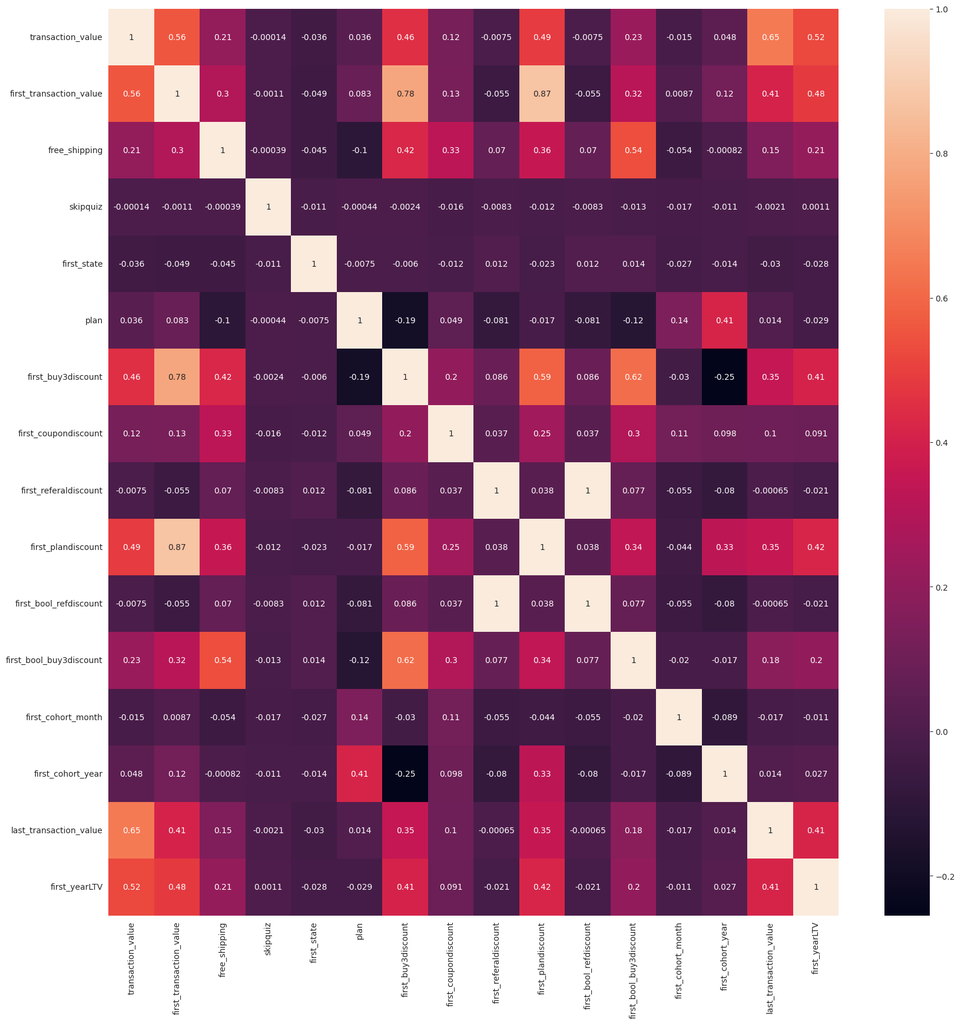

```python
corrMatrix = ocu_analytics.correlation_heatmap(orders,cat_vars=cat_fields)
```

### Check Correlations

Finds the unique combinations of highly correlated features.

Parameters:

- **corrMatrix** : The DataFrame with all the correlations generated from the correlation_heatmap function.
- **threshold** : The threshold to check combinations where the abs correlation coef is above the threshold value, by default .8.

```python
ocu_analytics.check_correlations(corrMatrix,threshold=.8)
```

```
                    feat1                    feat2  corr_coef
0      first_plandiscount  first_transaction_value     0.8709
1  first_bool_refdiscount    first_referaldiscount     1.0000
```

### Correlation Heatmap To Target Field

Prints a heatmap of Pearsons correlation coeficent for all features to the dependent variable.

Parameters:

- **df** : The -DataFrame with the data to be plotted.
- **cat_vars** : The list of categorical fields in the features list that need ot be encoded
- **target_field** : A field name that you want to correlate all the features to
- **features** : The list of fields you want to display on the correlation heatmap. By default features is none and will check correlations of all fields in the dataframe. If the user wants to check a subset of the df specify a list of stirng field names form the df as the features parameter.
- **filtered** : An optional value at which to cap the abs correlation coefficient
- **save_plot** : If you choose to save the plot it will be saved as a local byte stream which is then returned along with the correlation matrix df. When true the plot will not display.

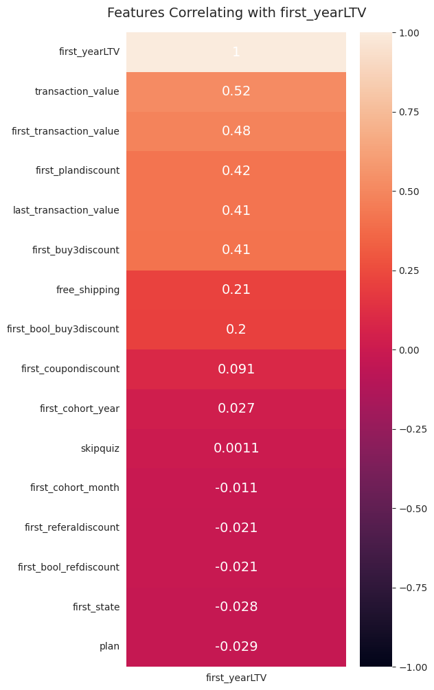

```python
corr=ocu_analytics.correlation_to_target_field(orders,cat_vars=cat_fields,target_field='first_yearLTV')
```

> **Tip:** Opening A Saved Plot Is Easy!

If you'd like to save a plot and suppress the plotted output inline, set `save_plot = True` and use the function `show_encoded_plot` to print the saved plot. This save plot parameter does not save static charts locally; instead, it saves as an encoded string and returns the plot for you to plot at your leisure. The plot is only saved in your Python code, where you currently have the variable set.

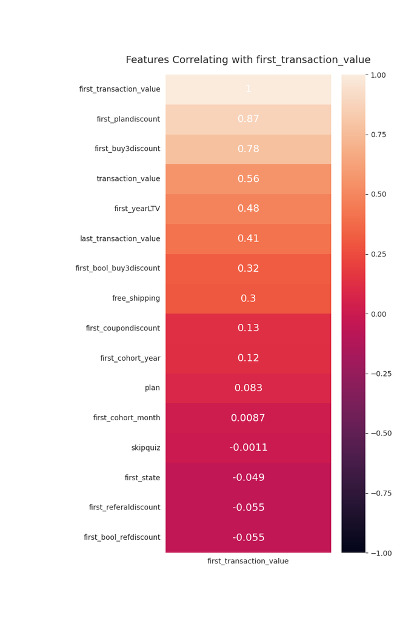

```python
corr,corr_plot=ocu_analytics.correlation_to_target_field(orders,cat_vars=cat_fields,target_field='first_transaction_value',save_plot=True)
ocu_analytics.easyviz.show_encoded_plot(corr_plot)
```

### Variance Inflation Factor

Multicollinearity test using vif.

Parameters:

- **df** : The DataFrame with one row per customer and their covariates and ltv
- **independent_variables** : List of features to check for multicollinearity
- **cat_feats** : List of features categorical features to encode

```python
ocu_analytics.vif(orders,independent_variables=['first_buy3discount', 'first_coupondiscount','first_referaldiscount', 'first_transaction_value',
                                                'free_shipping','skipquiz','first_state','plan','first_bool_refdiscount','first_bool_buy3discount'],
                  cat_feats=['free_shipping','skipquiz','first_state','plan','first_bool_refdiscount', 'first_bool_buy3discount'])
```

```
there exists 4 feature(s) with significant multicollinearity:

                               vif
first_transaction_value        inf
first_bool_buy3discount        inf
first_buy3discount       20.976378
first_coupondiscount      5.007251
```

### Repeat Purchase Rate

To find the rate at which customers are repeating purchases.

Parameters:

- **df** : A dataframe with all the customers orders. This function expects the df to have a column for first_transaction_date and customer_id.
- **activity_timeframe** : Number of days to allow a customer to make a repeat purchased. Will cut off all customers whose first order has not reached the activity timeframe.
- **group** : What to group the repeat purchase rate by. The group must be a field within the df, a common group is year cohort.
- **print_plot** : Default True. Will plot the group repeat purchase rate, if there is no group then there will be no plot to print.
- **path** : Defaults to None and the plot will display inline, else if true then the plot is saved as a html and not displayed inline. If the print_plot is false then that will override this parameter to None.

```python
ocu_analytics.repeat_purchase_rate(orders,activity_timeframe=30,group=None,print_plot=True,path=None)
```

|  | isRepeat | count_group | total | percent |
| --- | --- | --- | --- | --- |
| 0 | 0 | 8388 | 42279 | 19.84 |
| 1 | 1 | 33891 | 42279 | 80.16 |

```python
repurchase_rate,group_repurchase_rate=ocu_analytics.repeat_purchase_rate(orders,activity_timeframe=30,group='first_cohort_year',print_plot=True,path=None)
```

[interactive chart not shown]

```
Repeat purchase rate for all customers:

   isRepeat  count_group  total  percent
0         0         8388  42279    19.84
1         1        33891  42279    80.16
```

### Survival Rates

To find retention rates of customers for the months they are active as a customer and number of orders.

Parameters:

- **df** : A dataframe with all the customers order. This function expects the df to have a column for transaction_id, first_transaction_date, last_transaction_date and customer_id.
- **print_plot** : Default True. Will plot in line
- **save_plot** : Defaults to False, and the plot will display inline; else, if true, then the plot is saved to a local byte string and returned and will not display inline. If the print_plot is false, then this parameter will be ineffective.

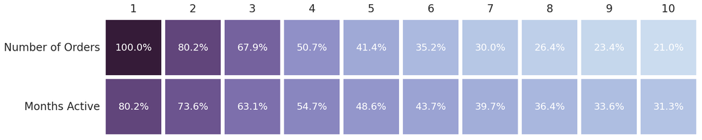

```python
retention = ocu_analytics.survival_rates(orders, print_plot=True, save_plot=False)
```

### Survival Rates for Groups

To find retention rates of customers for the months they are active as a customer and number of orders.

Parameters:

- **df** : A dataframe with all the customers order. This function expects the df to have a column for transaction_id, first_transaction_date, last_transaction_date and customer_id.
- **group** : A field name in the data frame for the group you'd like to calculate the retention rates. A common group is year cohorts.
- **print_plot** : Default True. Will plot in line
- **plot_type** : Default = 'order retention'. There are only two options for this parameter 1. 'order retention' or 2. 'months retention' and if given an incorrect type this function will throw an error and not produce a plot.
- **save_plot** : Defaults to False, and the plot will display inline; else, if true, then the plot is saved to a local byte string and returned and will not display inline. If the print_plot is false, then this parameter will be ineffective.
- **num_columns** : Defaults to 10. This number will tell the function how many months of retentions to plot or how many orders to plot.

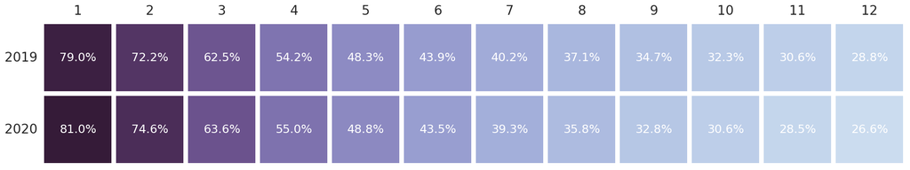

```python
months_retention_by_year_cohort = ocu_analytics.survival_rates_by_group(orders, group='first_cohort_year', print_plot=True,plot_type='months retention' ,save_plot=False,num_columns=12)
```

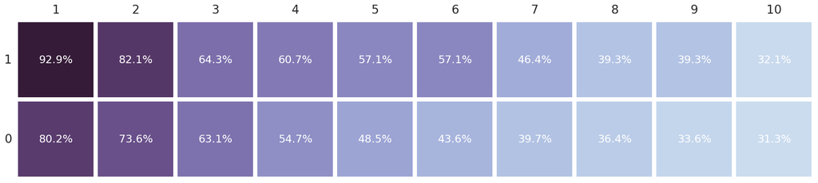

```python
orders_retention_by_skipquiz = ocu_analytics.survival_rates_by_group(orders, group='skipquiz', print_plot=True,plot_type='months retention' ,save_plot=False)
```

### LTV_Calculations 📱

This easy-to-use Python package calculates high LTV and inactivity time thresholds.

#### Main Features

Here are the things LTV_Calculations does well:

- Calculates the number of days between orders whereafter a customer is considered inactive.
- Calculate a dollar threshold amount a customer must spend to be considered high LTV.
- Calculates total LTV based on timeframe

#### inactivity_time_frame

This function expects three parameters:

- **df:** the cleaned order df with one row per order
- **id_field:** a string name of the customer id to use
- **order_date_field:** the string name of the date column associated with an order

- **threshold:** double value at which frequency distribution to cut. By default, it calculates at the 95th percentile
- **years_of_orders:** The number of years back of orders you'd like to calculate the threshold on. Default is 2 years
- **print_dist:** boolean value default True. prints the histogram and distribution of the inactivity time frame
- **print_dist:** prints the histogram and distribution of the inactivity time frame, default True
- **save_plot:** Defaults to False, and the plot will display inline; else, if true, then the plot is saved to a local byte string and returned and will not display inline. If the print_plot is false, then this parameter will be ineffective.

```
count    4685.00
mean       58.70
std        47.17
min         5.00
10%        30.00
20%        30.50
30%        33.73
40%        37.61
50%        42.75
60%        49.50
70%        60.00
80%        73.53
90%       102.60
max       497.00
Name: avg_days_between_orders, dtype: float64
```

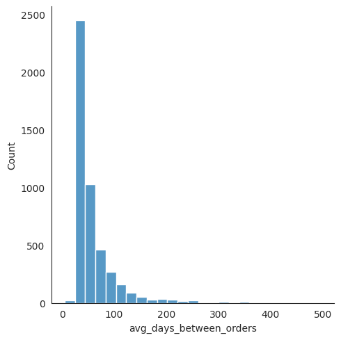

```
The number of days before a customer is considered inactive is 138 days
```

```python
from ocurate.analytics import LTV_Calculations
inactivity_days = LTV_Calculations.inactivity_time_frame(orders,threshold=.95,years_of_orders=2,print_dist=True,save_plot=False)
```

#### high_ltv_thresh

- **df:** the cleaned order df with one row per order sorted by user and order date
- **id_field:** a string name of the customer id to use
- **first_order_date_field:** the string name of the first order date column associated with a user
- **order_date_field:** the string name of the date column associated with an order
- **time_frame:** the inactivity days calculated by the inactivity_time_frame function

- **threshold:** double value at which frequency distribution to cut. By default, it calculates at the 80th percentile
- **years_of_orders:** The number of years back of orders you'd like to calculate the threshold on. Default is 2 years
- **print_plot:** boolean value default True. prints a plot of the transaction value by percentile
- **path:** Default is none, but if not none then save the interactive plot to an html file and the other to a byte stream.

```
0     Top 90% of tt_transaction_value bring 99.0% of...
1     Top 85% of tt_transaction_value bring 98.0% of...
2     Top 80% of tt_transaction_value bring 97.0% of...
3     Top 75% of tt_transaction_value bring 96.0% of...
4     Top 70% of tt_transaction_value bring 95.0% of...
5     Top 65% of tt_transaction_value bring 93.0% of...
6     Top 60% of tt_transaction_value bring 91.0% of...
7     Top 55% of tt_transaction_value bring 88.0% of...
8     Top 50% of tt_transaction_value bring 85.0% of...
9     Top 45% of tt_transaction_value bring 81.0% of...
10    Top 40% of tt_transaction_value bring 77.0% of...
11    Top 35% of tt_transaction_value bring 72.0% of...
12    Top 30% of tt_transaction_value bring 66.0% of...
13    Top 25% of tt_transaction_value bring 60.0% of...
14    Top 20% of tt_transaction_value bring 52.0% of...
15    Top 15% of tt_transaction_value bring 43.0% of...
16    Top 10% of tt_transaction_value bring 33.0% of...
17    Top 5% of tt_transaction_value bring 20.0% of ...
18    Top 0% of tt_transaction_value bring 0.0% of t...
Name: Percentiles, dtype: object
```

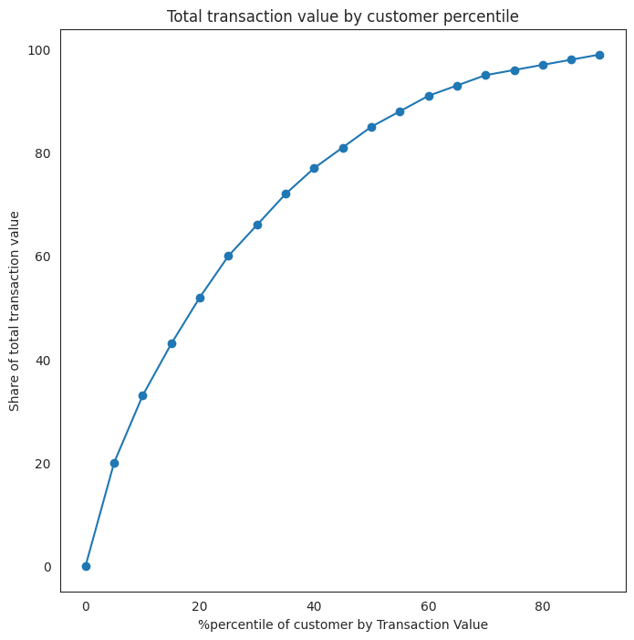

[interactive chart not shown]

```python
high_ltv_threshold = LTV_Calculations.high_ltv_thresh(orders, inactivity_days, threshold=0.8, years_of_orders=2, print_plot=True)
```

#### N Year LTV

Pulls individual-level total N year LTV up to date from sample client orders data.

Disclaimer: for clients where negative transactions are capped at 0.01 for model training and inference,historical LTV does **NOT** cap negative values.

Parameters:

- **ords:** all orders data from the data module function get_orders_data(). Ords must have the fields

`['customer_id', 'transaction_id', 'transaction_date', 'transaction_value', 'first_transaction_date']`

- **N** : How many years of LTV to calculate, by default this function will calculate first year LTV.
- **exclude_first:** do you want to include or exclude the first transaction value by default false.
- **cut_off_new_cust:** will remove customers who have yet to reach one year of customership, by default true.

```python
first_yearltv=ocu_analytics.LTV_Calculations.get_historical_N_year_LTV(orders,N=1,exclude_first=False, cut_off_new_cust=True)
```

#### Historical LTV

Pulls individual-level *total* historical LTV up to date from sample client orders data.

Disclaimer: for clients where negative transactions are capped at 0.01 for model training and inference,historical LTV does **NOT** cap negative values.

Parameters:

- **ords:** all orders data from the data module function get_orders_data(). Ords must have the fields

`['customer_id', 'transaction_id', 'transaction_date', 'transaction_value', 'first_transaction_date']`

- **exclude_first:** do you want to include or exclude the first transaction value by default false.

```python
ltv=LTV_Calculations.get_historical_LTV(orders,exclude_first=False)
```

### Visulizations

#### Interactive Line Plot

This function will plot an interactive line chart using plotly.

Parameters:

- **df** : DataFrame The data to be plotted.
- **x_field** : string The name of the field in the df for the x axis. This line chart is best suited for plotting time seires so try using a datetime dytpe for x_field.
- **y_field** : string The name of the field in the df for the y axis. The function will not group by and calculate aggregates so it expects that the y value is already aggregated.
- **color_field** : string, Optional A field in the df that will color code different lines depending on how many categories are in the color field. Dy default there is no color field and will only be one line.
- **chart_title_string** : string, Optional The chart title, by default no title
- **y_tick_format** : string, Optional By default the format is ',.0f' which will round the values on the y axis to the nearest whole number and add a comma. Other common formats are '$,.0f' for USD, ',.0f%' for percents between 0-100%, and '.2f' for floats rounded to the second decimal place with no comma formatting.
- **path** : string, Optional The path of where to save the html plot, the path should include the name of the file and the .html extension.
- **hover_data_fields** : dict or list, Optional By default is blank and no data will show on hover. The hover_data argument accepts a list of column names to be added to the hover tooltip (in addition to the y and x fields), or a dictionary for advanced formatting. The hover_name property controls which column is displayed in bold as the tooltip title. hover_data_fields can also be a dictionary. Its keys are existing columns of the dataframe argument, or new labels. For an existing column, the values can be:
  - False to remove the column from the hover data (for example, if one wishes to remove the column of the x argument)
  - True to add a different column, with default formatting
  - a formatting string starting with : for numbers d3-format's syntax, and | for dates in d3-time-format's syntax, for example :.3f, |%a.

- **xtitle** : string, Optional The name of the x-axis title, by default it'll be the name of the x_field passed in.

```python
monthly = orders.groupby(["first_cohort_month_year"]).agg(first_yearALTV=('first_yearLTV', 'mean'),
                                                                   first_aov=('first_transaction_value',
                                                                              'mean')).reset_index()
```

```python
ocu_analytics.easyviz.interactive_line_plot(monthly,x_field='first_cohort_month_year',y_field='first_yearALTV',hover_data_fields=['first_aov'])
```

[interactive chart not shown]

```python
ocu_analytics.easyviz.interactive_line_plot(monthly,x_field='first_cohort_month_year',y_field='first_yearALTV',y_tick_format='$,.2f',
                                            chart_title_string='First Year Avg LTV by Cohort',xtitle='First Order Month Cohort',
                                            hover_data_fields={'first_cohort_month_year':False,'first_aov':':$.2f'})
```

[interactive chart not shown]

```python
monthly_skipquiz = orders.groupby(["first_cohort_month_year","skipquiz"]).agg(first_yearALTV=('first_yearLTV', 'mean'),
                                                                   first_aov=('first_transaction_value',
                                                                              'mean')).reset_index()
```

```python
ocu_analytics.easyviz.interactive_line_plot(monthly_skipquiz,x_field='first_cohort_month_year',y_field='first_yearALTV',color_field='skipquiz',y_tick_format='$,.2f',
                                            chart_title_string='First Year Avg LTV for Customers Who Took The Quiz or Opted Out',xtitle='First Order Month Cohort',
                                            hover_data_fields={"first_cohort_month_year": False, 'first_yearALTV': ':$.2f'})
```

[interactive chart not shown]

#### Interactive Bar Chart

This function will plot an interactive bar chart using plotly.

Parameters:

- **df** : The data to be plotted.
- **x_field** : The name of the field in the df for the x axis.
- **y_field** : The name of the field in the df for the y axis. The function will not group by and calculate aggregates so it expects that the y value is already aggregated.
- **hover_data_fields** : By default is blank and no data will show on hover. The hover_data argument accepts a list of column names to be added to the hover tooltip (in addition to the y and x fields), or a dictionary for advanced formatting. The hover_name property controls which column is displayed in bold as the tooltip title. hover_data_fields can also be a dictionary. Its keys are existing columns of the dataframe argument, or new labels. For an existing column, the values can be:
  - False to remove the column from the hover data (for example, if one wishes to remove the column of the x argument)
  - True to add a different column, with default formatting
  - a formatting string starting with : for numbers d3-format's syntax, and | for dates in d3-time-format's syntax, for example :.3f, |%a.

  *Example*:

  ```
  hover_data_fields={'species':False, # remove species from hover data
               'sepal_length':':.2f', # customize hover for column of y attribute
               'petal_width':True, # add other column, default formatting
               'sepal_width':':.2f', # add other column, customized formatting
               # data not in dataframe, default formatting
               'suppl_1': np.random.random(len(df)),
               # data not in dataframe, customized formatting
               'suppl_2': (':.3f', np.random.random(len(df)))
              }
  ```

- **chart_title_string** : The chart title, by default no title
- **path** : The path of where to save the html plot, the path shopuld include the name of the file and the .html extension.
- **y_tick_format** : By default the format is ',.0f' which will round the values on the y axis to the nearest whole number and add a comma. Other common formats are '$,.0f' for USD, ',.0f%' for percents between 0-100%, and '.2f' for floats rounded to the second decimal place with no comma formatting.
- **xtitle** : The name of the x-axis title, by default it'll be the name of the x_field passed in.

```python
customer_counts_yearly = orders.groupby(["first_cohort_year"]).agg(num_customers=('customer_id', 'nunique'),
                                                                   first_aov=('first_transaction_value',
                                                                              'mean')).reset_index()
```

```python
ocu_analytics.easyviz.interactive_bar_chart(customer_counts_yearly,x_field="first_cohort_year", y_field = "num_customers",
                           hover_data_fields={"first_cohort_year":False,"first_aov":':$.2f','num_customers':True},
                      chart_title_string='Yearly Customers Acquired',y_tick_format=',.0f')
```

[interactive chart not shown]

#### Nice Bar Plot

A simple *not interactive* labeled bar chart for a single aggregated field.

Parameters:

- **df** : The aggregated df of values to plot
- **x_field** : The name of the field in the df for the x axis.
- **y_field** : The name of the field in the df for the y axis.
- **orientation** : By default will plot a vertical bar on the x-axis but if you'd like a horizontal bar chart then the orientation will be 'horizontal'.
- **type** : The data type format for the labels. By default, will plot a 'whole' number with commas. Other options are 'percent' and 'monetary'

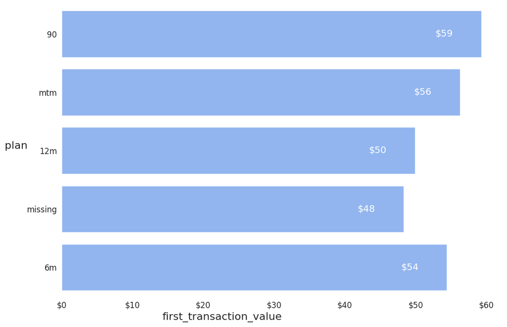

```python
ocu_analytics.easyviz.nice_bar_plot(orders, x_field='plan', y_field='first_transaction_value',orientation='horizontal',type='monetary')
```

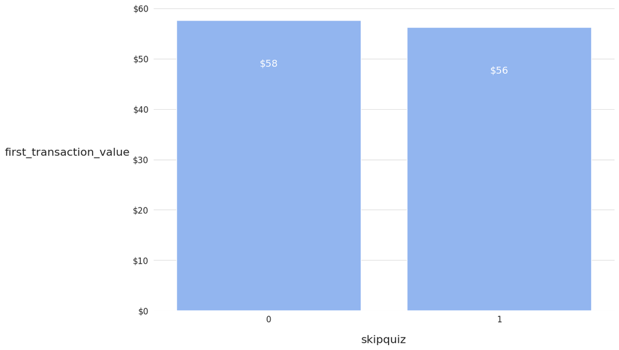

```python
ocu_analytics.easyviz.nice_bar_plot(orders, x_field='skipquiz', y_field='first_transaction_value',type='monetary')
```

#### Nice Count Plot

A simple *not interactive* labeled count chart. Shows the counts of observations in each categorical bin using bars. A count plot can be thought of as a histogram across a categorical, instead of quantitative, variable.

Parameters:

- **df** : The aggregated df of values to plot
- **field** : the aggregated field name from teh df to be plotted
- **field_label** : The name of the =axis title, by default it'll be the name of the field passed in.
- **orientation** : By default will plot a vertical bar on the x-axis but if you'd like a horizontal bar chart then the orientation will be 'horizontal'.
- **type** : The data type format for the labels. By default, will plot a whole number with commas. Other options are 'percent' and 'monetary'

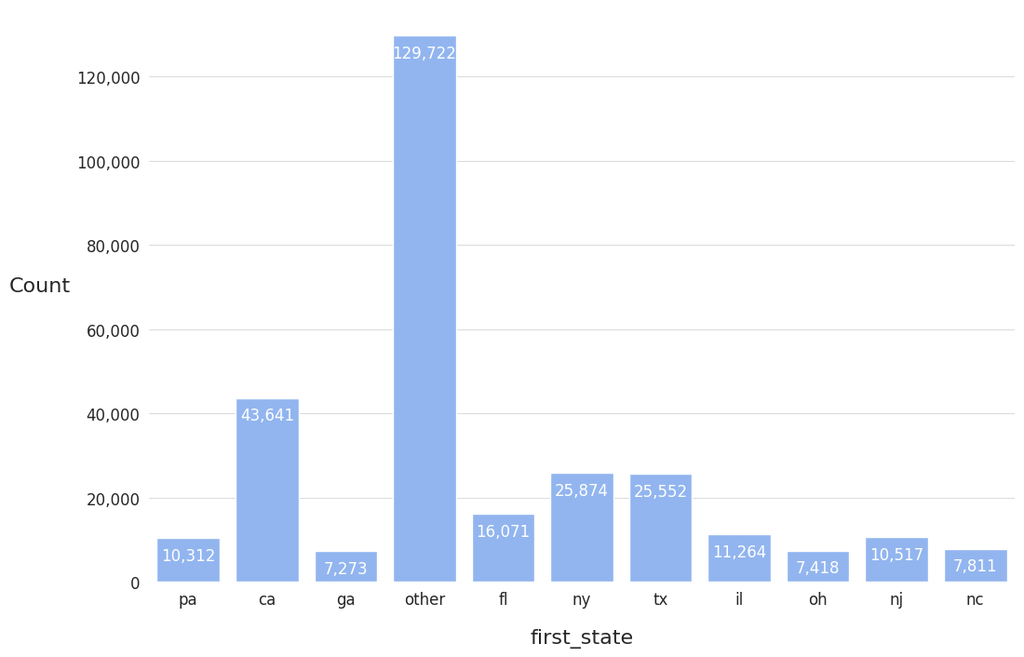

```python
ocu_analytics.easyviz.nice_count_plot(orders, field='first_state')
```

#### Single Histogram

This function prints one plot with one or many fields histogram

Paramaters:

- **df** : The df with the data to be plotted
- **dist_fields** : A list of field names in the df to plot the distribution of. It is recommended that you use fields that are on the same scale like AOV and first order average.
- **save_plot** : Defaults to False, and the plot will display inline; else, if true, then the plot is saved to a local byte string and returned and will not display inline.

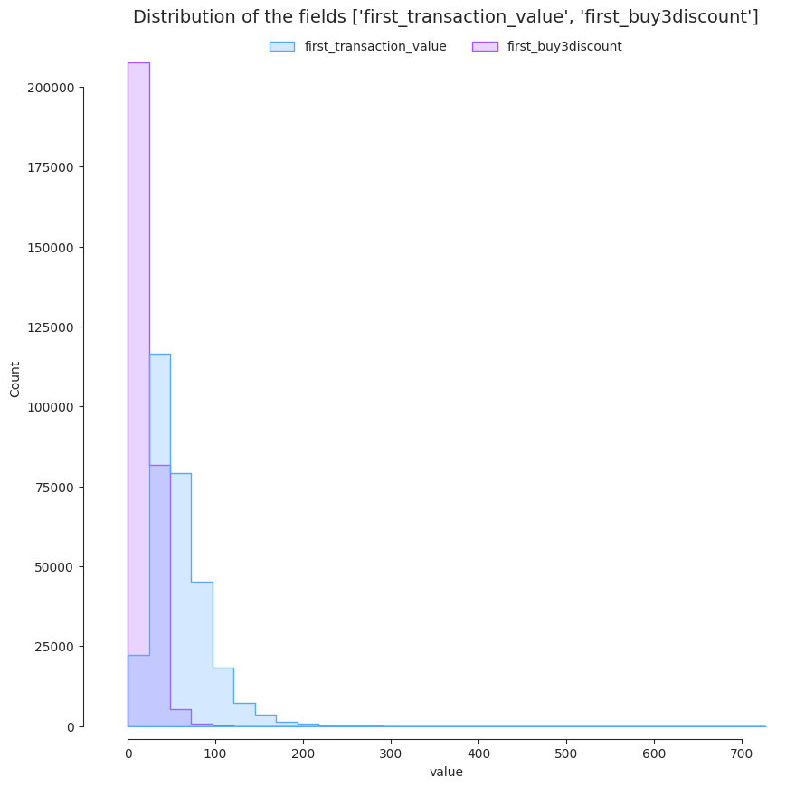

```python
ocu_analytics.easyviz.single_histogram(orders, dist_fields=['first_transaction_value','first_buy3discount'], save_plot=False)
```

#### Multi Histogram

Create multiple histograms on separate charts and will plot the outliers in the title of the chart using IQR

Parameters

- **df** : The dataframe containing the data to find the distributions of.
- **dist_fields** : A List of field names from the input df to be plotted.
- **bins** : default 50. Generic bin parameter that can be the name of a reference rule, the number of bins, or the breaks of the bins.
- **format** : how to format the Y axis. by default 'monetary' other options include : 'whole number' and 'rounded float'.
- **save_plot** : default false. If set to true then the plot is saved as byte stream and not shown inline.

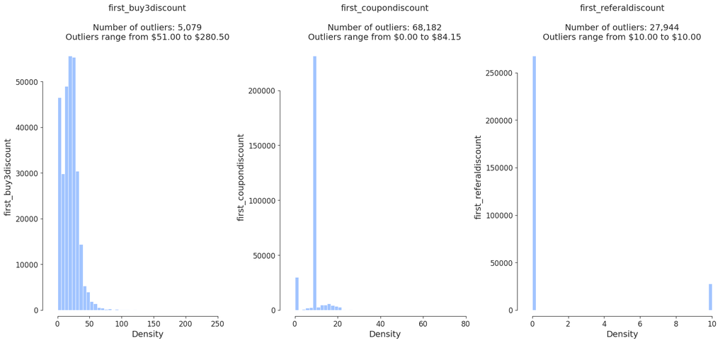

```python
ocu_analytics.easyviz.multi_histogram(orders,dist_fields=['first_buy3discount', 'first_coupondiscount','first_referaldiscount'],save_plot=False)
```

> **Tip**

> Opening A Saved Plot Is Easy!

If you'd like to save a plot and suppress the plotted output inline, set save_plot = True and use the function show_encoded_plot to print the saved plot. This save plot parameter does not save static charts locally; instead, it saves as an encoded string and returns the plot for you to plot at your leisure. The plot is only saved in your Python code, where you currently have the variable set.

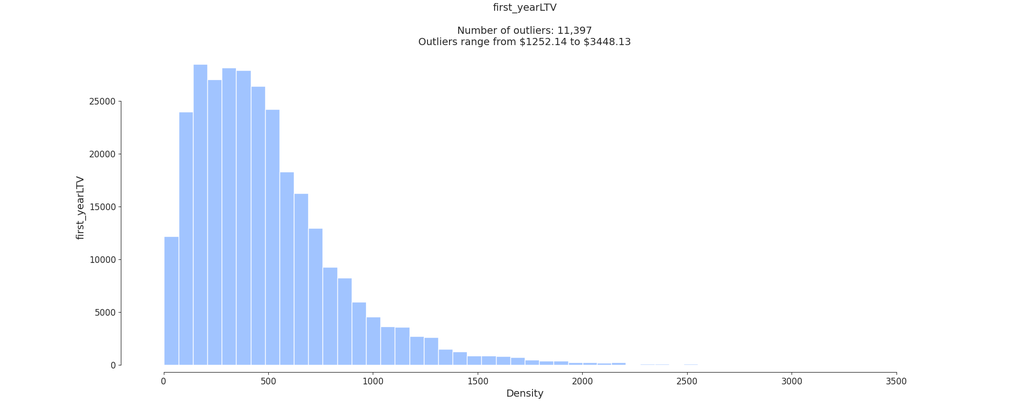

```python
saved_hist=ocu_analytics.easyviz.multi_histogram(orders,dist_fields=['first_yearLTV'],save_plot=True)
ocu_analytics.easyviz.show_encoded_plot(saved_hist)
```

#### Bivariate Analysis

This function performs bivariate analysis between all pairs of numerical and categorical fields. The numerical fields will create a pair plot with all combinations of numerical fields, and the numerical and categorical fields will create a violin plot for each combination of numerical and categorical fields. Since violin plots are computationally expensive, this function will only plot a violin plot for those categorical variables distributed evenly. If a categorical field has 85% or more categories in one category, this function removes it from the bivariate analysis.

Parameters:

- **df** : The dataframe with the data to be analyzed
- **num_fields** : a list of numerical fields, this is optional and if not sent in then the function will look for all fields with the tpye int and float. If specified we will fill nulls with 0 and set type to float. These are the fields to be used in the bivariate analysis.
- **cat_fields** : a list of categorical fields, this is optional and if not sent in then the function will look for all fields with the tpye string and object. If specified we will fill nulls with 'missing' and set type to string. These are the fields to be used in the bivariate analysis.
- **save_plot** : default false. If set to true then the plot is saved as byte stream and not shown inline

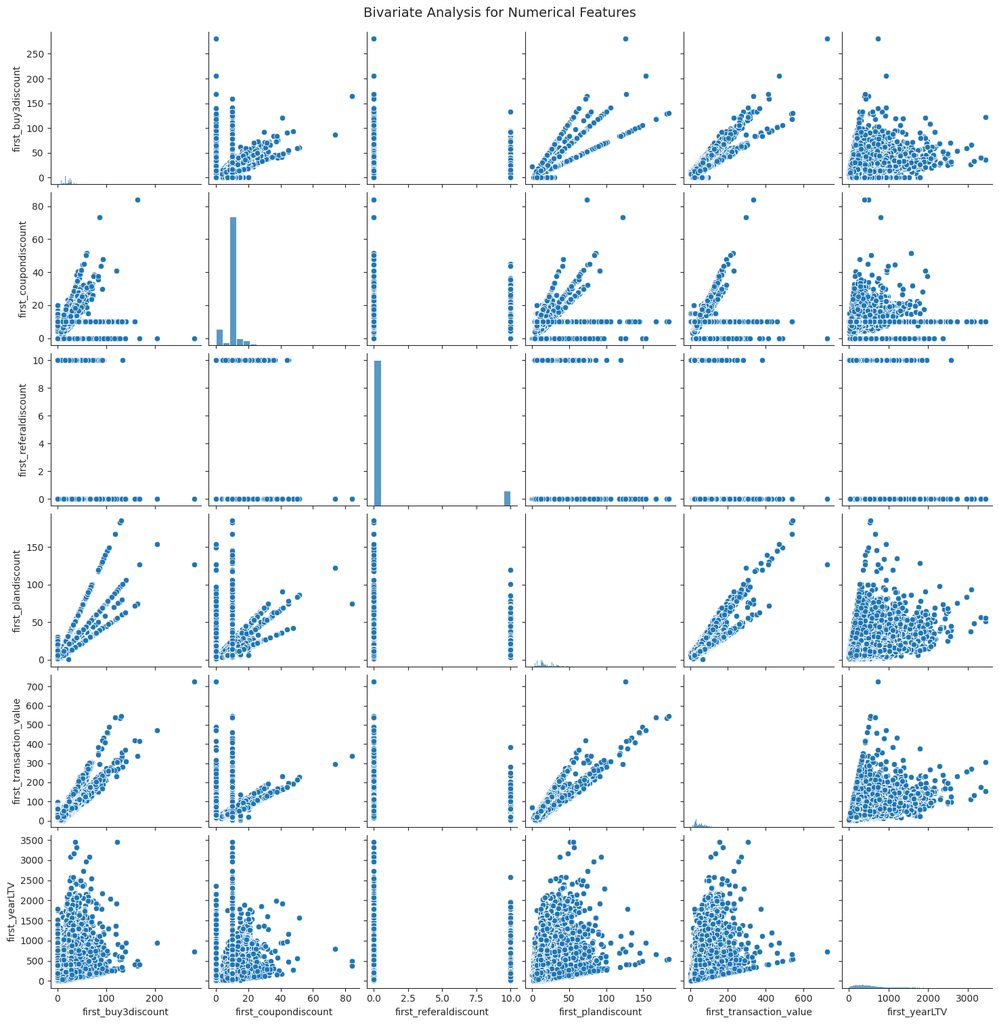

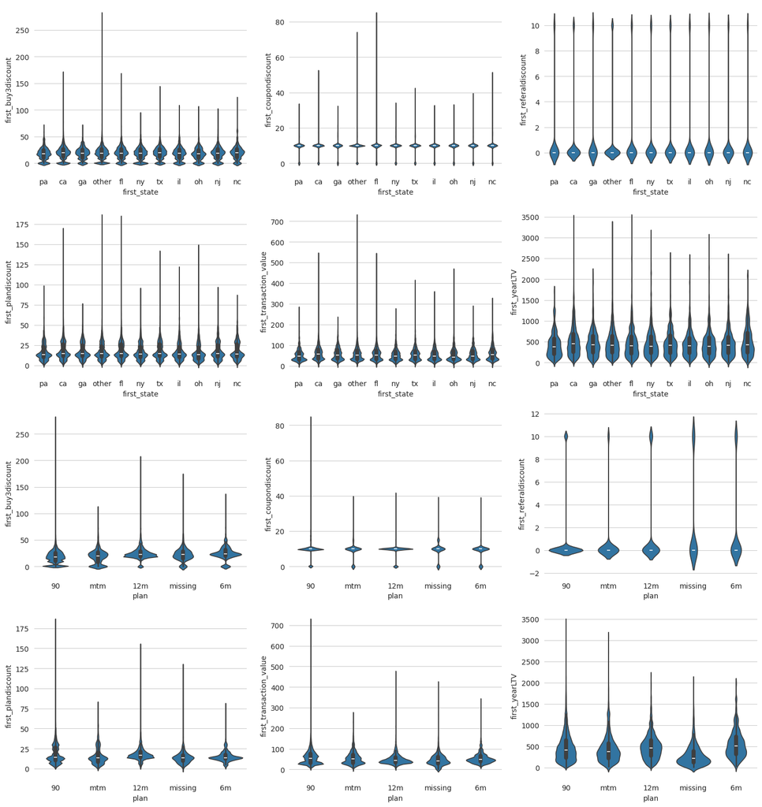

```python
ocu_analytics.easyviz.bivariate_analysis(orders, num_fields=num_fields, cat_fields=cat_fields, save_plot=False)
```

#### Multivariate Violin Plot

This function creates several violin plots for each combination of numerical and categorical fields. Since violin plots are computationally expensive, this function will only plot a violin plot for those categorical variables distributed evenly. If a categorical field has 85% or more categories in one category, this function removes it from the bivariate analysis.

Parameters:

- **df** : The dataframe with the data to be analyzed
- **hue_field** : A string name of the grouping field in the df that will produce points with different colors. Can be either categorical or numeric, although color mapping will behave differently in latter case.
- **num_fields** : A list of numerical fields, this is optional and if not sent in then the function will look for all fields with the tpye int and float. If specified we will fill nulls with 0 and set type to float. These are the fields to be used in the bivariate analysis.
- **cat_fields** : A list of categorical fields, this is optional and if not sent in then the function will look for all fields with the tpye string and object. If specified we will fill nulls with 'missing' and set type to string. These are the fields to be used in the bivariate analysis.
- **save_plot** : Default false. If set to true then the plot is saved as byte stream and not shown inline

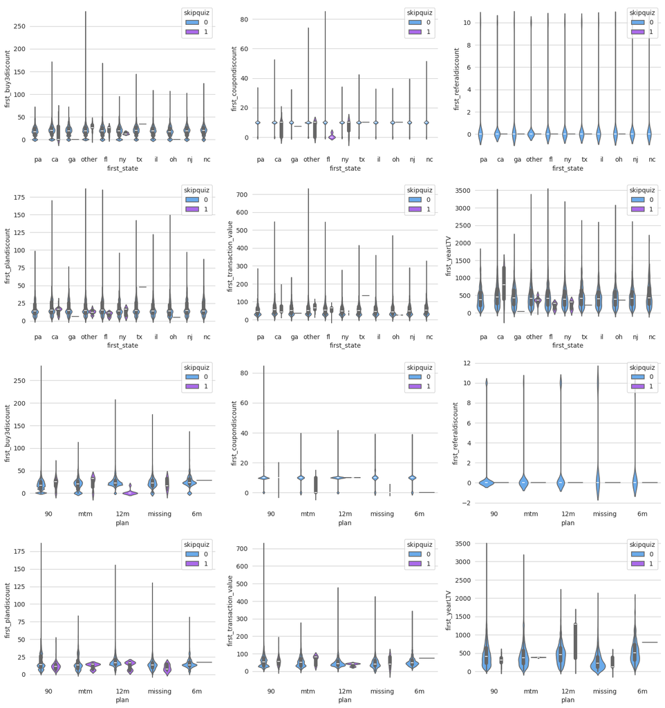

```python
ocu_analytics.easyviz.multivar_violin_plot(orders, hue_field='skipquiz', num_fields=num_fields,
                                           cat_fields=['free_shipping','first_state','plan','first_bool_refdiscount','first_bool_buy3discount'],
                                           save_plot=False)
```